# R Solo Project: School Districts

# Imports

```r
library(tidyverse)
library(corrr)
library(readxl)
```

# Exercises

## Problem 1

Read in districts.csv into a tibble named districts. How many rows and columns does it contain?

```r
districts <- read_csv('../data/districts.csv')
str(districts)
```

```
spec_tbl_df [146 x 27] (S3: spec_tbl_df/tbl_df/tbl/data.frame)
 $ system       : num [1:146] 0 10 11 12 20 30 40 50 51 52 ...
 $ system_name  : chr [1:146] "State of Tennessee" "Anderson County" "Clinton City" "Oak Ridge City" ...
 $ alg_1        : num [1:146] 70 76.1 NA 76.9 64.3 73.7 64.8 73.2 82.2 83.8 ...
 $ alg_2        : num [1:146] 54.3 63.3 NA 72 42.4 58.4 73.9 59.8 76.8 77.3 ...
 $ bio          : num [1:146] 65.3 73.6 NA 83.5 62.1 77.1 73 65.1 88 92.1 ...
 $ chem         : num [1:146] 44.2 41 NA 80.9 32.5 33.1 19.5 45.4 66 80.4 ...
 $ ela          : num [1:146] 48.4 45.7 58.3 56.1 44.1 46 35.4 46.3 50.2 69.6 ...
 $ eng_1        : num [1:146] 71.8 73.7 NA 86.7 72.3 75.4 63.6 71.8 85.5 89.9 ...
 $ eng_2        : num [1:146] 64.8 59.2 NA 74.6 63.1 60.8 53.3 66 79.6 82.7 ...
 $ eng_3        : num [1:146] 41.7 38.2 NA 53.8 44.6 45.6 50 45.3 67.2 68.1 ...
 $ math         : num [1:146] 54.7 54 68.9 55.3 53.1 53.9 41.1 50.5 56.6 70.2 ...
 $ science      : num [1:146] 64.5 64.5 69.6 70.8 61.8 65 56.2 68.4 65.1 87.1 ...
 $ enrollment   : num [1:146] 943699 6304 894 4326 8270 ...
 $ black        : num [1:146] 24.1 2.8 5.7 16.6 11.2 3.9 1.5 3 23.3 4.2 ...
 $ hispanic     : num [1:146] 8.5 1.1 2.8 8 20.6 2.1 6.8 4.2 9.5 4 ...
 $ native       : num [1:146] 0.3 0.5 0.3 0.7 0.5 0.3 0.6 0.4 0.6 0.2 ...
 $ el           : num [1:146] 4.6 0.2 1 3 9.4 0 2.3 1.9 2.7 2.8 ...
 $ swd          : num [1:146] 14 18 18.1 14.3 10.9 18.8 19.7 12.8 13 13.2 ...
 $ ed           : num [1:146] 57.9 58.5 63.4 52.5 69.9 50.2 83.5 54.2 49.4 32.1 ...
 $ expenditures : num [1:146] 9375 9536 9538 12356 7756 ...
 $ act_composite: num [1:146] 19.4 19.9 NA 23.1 18.4 18.4 19.2 19.7 22 23 ...
 $ chronic_abs  : num [1:146] 13.2 11.5 8.8 17.5 8.6 6.5 9.1 17 4.7 2 ...
 $ suspended    : num [1:146] 6.2 5 1.2 5.7 2.2 0 2.4 4.7 3.1 2.7 ...
 $ expelled     : num [1:146] 0.2 0.1 0 0 0 0 0.1 0.1 0.1 0 ...
 $ grad         : num [1:146] 87.2 94 NA 89.7 90.8 94.5 92.4 89.1 98.2 96.6 ...
 $ dropout      : num [1:146] 8.4 4.2 NA 4.4 5.4 3 6.9 9.2 0.9 3.1 ...
 $ region       : chr [1:146] NA "East TN" "East TN" "East TN" ...
 - attr(*, "spec")=
  .. cols(
  ..   system = col_double(),
  ..   system_name = col_character(),
  ..   alg_1 = col_double(),
  ..   alg_2 = col_double(),
  ..   bio = col_double(),
  ..   chem = col_double(),
  ..   ela = col_double(),
  ..   eng_1 = col_double(),
  ..   eng_2 = col_double(),
  ..   eng_3 = col_double(),
  ..   math = col_double(),
  ..   science = col_double(),
  ..   enrollment = col_double(),
  ..   black = col_double(),
  ..   hispanic = col_double(),
  ..   native = col_double(),
  ..   el = col_double(),
  ..   swd = col_double(),
  ..   ed = col_double(),
  ..   expenditures = col_double(),
  ..   act_composite = col_double(),
  ..   chronic_abs = col_double(),
  ..   suspended = col_double(),
  ..   expelled = col_double(),
  ..   grad = col_double(),
  ..   dropout = col_double(),
  ..   region = col_character()
  .. )
 - attr(*, "problems")=<externalptr>
```

### Answer 1

Rows: 146 Columns: 27

## Problem 2

Notice that the first row corresponds to the whole State of Tennessee. Remove this row and save the result back to districts.

```r
districts <- districts %>%
  filter(system_name != "State of Tennessee")
```

## Problem 3

How many districts have a proficiency rate of at least 80% for both alg_1 and eng_1?

```r
districts %>%
  filter(alg_1 >= 80 & eng_1 >= 80)
```

| system | system_name | alg_1 | alg_2 | bio | chem | ela | eng_1 | eng_2 | eng_3 | math | science | enrollment | black | hispanic | native | el | swd | ed | expenditures | act_composite | chronic_abs | suspended | expelled | grad | dropout | region |
| --- | --- | --- | --- | --- | --- | --- | --- | --- | --- | --- | --- | --- | --- | --- | --- | --- | --- | --- | --- | --- | --- | --- | --- | --- | --- | --- |
| 51 | Alcoa City | 82.2 | 76.8 | 88.0 | 66.0 | 50.2 | 85.5 | 79.6 | 67.2 | 56.6 | 65.1 | 1850 | 23.3 | 9.5 | 0.6 | 2.7 | 13.0 | 49.4 | 10320.0 | 22.0 | 4.7 | 3.1 | 0.1 | 98.2 | 0.9 | East TN |
| 52 | Maryville City | 83.8 | 77.3 | 92.1 | 80.4 | 69.6 | 89.9 | 82.7 | 68.1 | 70.2 | 87.1 | 4944 | 4.2 | 4.0 | 0.2 | 2.8 | 13.2 | 32.1 | 10161.2 | 23.0 | 2.0 | 2.7 | 0.0 | 96.6 | 3.1 | East TN |
| 273 | Trenton SSD | 91.6 | 84.7 | 75.6 | 64.5 | 44.6 | 82.6 | 76.0 | 50.6 | 62.9 | 53.6 | 1278 | 28.2 | 6.0 | 0.0 | 0.1 | 12.7 | 66.1 | 8916.6 | 18.6 | 10.5 | 2.8 | 0.0 | 83.5 | 11.0 | Northwest |
| 274 | Bradford SSD | 94.4 | 92.6 | 87.9 | 66.7 | 56.5 | 81.8 | 68.4 | 70.4 | 73.4 | 75.4 | 499 | 6.1 | 0.6 | 0.0 | 0.0 | 17.3 | 62.8 | 10143.5 | 18.7 | 11.4 | 0.9 | 0.0 | 100.0 | 0.0 | Northwest |
| 275 | Gibson County SSD | 83.7 | 73.2 | 75.3 | 63.0 | 57.8 | 83.8 | 73.5 | 59.6 | 67.5 | 79.7 | 3832 | 7.8 | 2.0 | 0.0 | 0.4 | 13.3 | 42.3 | 7270.0 | 19.7 | 8.2 | 0.0 | 0.0 | 94.9 | 4.0 | Northwest |
| 301 | Greeneville City | 83.2 | 90.2 | 77.7 | 86.1 | 59.3 | 87.3 | 75.1 | 66.0 | 65.5 | 74.2 | 2674 | 9.8 | 7.8 | 0.9 | 3.0 | 16.6 | 47.2 | 10862.5 | 21.3 | 9.1 | 4.5 | 0.0 | 98.6 | 0.5 | First TN |
| 390 | Henderson County | 86.0 | 88.4 | 76.4 | 53.7 | 53.3 | 81.1 | 77.7 | 51.8 | 72.1 | 71.2 | 3781 | 8.1 | 2.2 | 0.0 | 0.0 | 14.5 | 61.4 | 8412.5 | 19.5 | 10.8 | 0.0 | 0.0 | 96.4 | 2.4 | Southwest/Memphis |
| 793 | Arlington City | 88.0 | 66.9 | 82.5 | 49.8 | 75.7 | 88.8 | 78.1 | 50.7 | 75.1 | 88.3 | 4819 | 16.0 | 5.3 | 0.4 | 2.2 | 11.0 | 13.9 | 7705.1 | 21.1 | 7.9 | 2.3 | 0.1 | 94.0 | 4.4 | Southwest/Memphis |
| 795 | Collierville City | 90.2 | 85.6 | 87.4 | 80.4 | 75.1 | 92.5 | 86.2 | 66.2 | 75.7 | 86.8 | 7774 | 17.5 | 4.3 | 0.4 | 4.0 | 13.4 | 15.0 | 8383.2 | 24.0 | 5.9 | 2.8 | 0.3 | 93.0 | 2.7 | Southwest/Memphis |
| 796 | Germantown City | 90.0 | 84.2 | 88.9 | 78.5 | 79.4 | 90.8 | 87.7 | 70.8 | 74.3 | 88.0 | 5624 | 12.3 | 3.1 | 0.3 | 2.6 | 9.8 | 9.6 | 7930.8 | 24.1 | 5.1 | 1.3 | 0.0 | 88.7 | 7.9 | Southwest/Memphis |

[output cut: 3 more lines]

### Answer 3

13 school districts

4. How many districts have a proviciency rate less than 50% for either alg_1 or eng_1?

```r
districts %>%
  filter(alg_1 < 50 | eng_1 < 50)
```

| system | system_name | alg_1 | alg_2 | bio | chem | ela | eng_1 | eng_2 | eng_3 | math | science | enrollment | black | hispanic | native | el | swd | ed | expenditures | act_composite | chronic_abs | suspended | expelled | grad | dropout | region |
| --- | --- | --- | --- | --- | --- | --- | --- | --- | --- | --- | --- | --- | --- | --- | --- | --- | --- | --- | --- | --- | --- | --- | --- | --- | --- | --- |
| 240 | Fayette County | 39.7 | 14.7 | 56.1 | 20.2 | 32.6 | 58.9 | 53.2 | 35.4 | 36.1 | 41.1 | 3220 | 58.8 | 5.0 | 0.1 | 2.3 | 13.9 | 80.6 | 9125.9 | 16.6 | 14.5 | 12.9 | 0.0 | 80.6 | 15.9 | Southwest/Memphis |
| 310 | Grundy County | 47.9 | 41.7 | 51.9 | 41.9 | 32.4 | 62.0 | 62.0 | 36.7 | 37.8 | 47.7 | 2105 | 0.2 | 1.0 | 0.1 | 0.4 | 19.0 | 81.2 | 9087.9 | 17.6 | 18.1 | 0.3 | 0.0 | 90.0 | 5.3 | Southeast |
| 410 | Hickman County | 40.2 | 22.6 | 54.2 | 45.1 | 48.9 | 60.3 | 57.5 | 31.3 | 58.1 | 68.0 | 3439 | 3.2 | 1.7 | 0.5 | 0.6 | 18.1 | 69.1 | 8965.8 | 18.4 | 17.3 | 1.6 | 0.0 | 92.5 | 5.2 | South Central |
| 440 | Jackson County | 45.9 | 33.3 | 68.9 | 50.0 | 42.8 | 61.8 | 47.3 | 46.3 | 45.3 | 64.7 | 1505 | 0.9 | 1.5 | 0.3 | 0.0 | 19.7 | 83.4 | 9165.8 | 18.4 | 8.2 | 0.0 | 0.0 | 87.4 | 8.4 | Upper Cumberland |
| 480 | Lake County | 22.9 | NA | 25.0 | 36.5 | 32.5 | 36.8 | 34.6 | 31.7 | 34.7 | 45.6 | 807 | 30.2 | 3.3 | 0.1 | 0.1 | 18.6 | 77.0 | 10813.0 | 16.4 | 31.2 | 5.5 | 0.1 | 89.4 | 6.4 | Northwest |
| 680 | Perry County | 48.5 | 50.6 | 58.0 | 19.0 | 42.6 | 60.8 | 60.6 | 35.6 | 61.8 | 66.5 | 1058 | 3.2 | 2.1 | 0.8 | 0.0 | 17.1 | 71.7 | 9212.0 | 18.0 | 24.1 | 1.5 | 0.0 | 91.9 | 7.0 | South Central |
| 963 | Tenn School for Blind | 23.1 | NA | 25.0 | NA | 6.7 | 60.0 | NA | 20.0 | NA | 10.0 | NA | 16.1 | 9.8 | 0.0 | 1.4 | 94.4 | 32.9 | NA | NA | 41.3 | 0.0 | 0.0 | 11.1 | 0.0 | Mid Cumberland |
| 985 | Achievement School District | 34.0 | 20.4 | 20.6 | NA | 14.3 | 37.8 | 33.0 | 8.2 | 23.3 | 26.1 | 6370 | 96.7 | 1.5 | 0.0 | 1.1 | 12.9 | 96.6 | 12804.4 | 14.2 | 27.2 | 21.4 | 0.1 | 54.7 | 27.6 | Southwest/Memphis |

### Answer 4

8 districts

## Problem 5

Which district has the lowest graduation rate?

```r
districts %>%
  slice_min(grad, n = 1)
```

| system | system_name | alg_1 | alg_2 | bio | chem | ela | eng_1 | eng_2 | eng_3 | math | science | enrollment | black | hispanic | native | el | swd | ed | expenditures | act_composite | chronic_abs | suspended | expelled | grad | dropout | region |
| --- | --- | --- | --- | --- | --- | --- | --- | --- | --- | --- | --- | --- | --- | --- | --- | --- | --- | --- | --- | --- | --- | --- | --- | --- | --- | --- |
| 963 | Tenn School for Blind | 23.1 | NA | 25 | NA | 6.7 | 60 | NA | 20 | NA | 10 | NA | 16.1 | 9.8 | 0 | 1.4 | 94.4 | 32.9 | NA | NA | 41.3 | 0 | 0 | 11.1 | 0 | Mid Cumberland |

### Answer 5

The district with the lowest graduation rate is the Tennessee School for the Blind with 11.1%.

## Problem 6

Which district has the highest dropout rate?

```r
districts %>%
  slice_max(dropout, n = 1)
```

| system | system_name | alg_1 | alg_2 | bio | chem | ela | eng_1 | eng_2 | eng_3 | math | science | enrollment | black | hispanic | native | el | swd | ed | expenditures | act_composite | chronic_abs | suspended | expelled | grad | dropout | region |
| --- | --- | --- | --- | --- | --- | --- | --- | --- | --- | --- | --- | --- | --- | --- | --- | --- | --- | --- | --- | --- | --- | --- | --- | --- | --- | --- |
| 985 | Achievement School District | 34 | 20.4 | 20.6 | NA | 14.3 | 37.8 | 33 | 8.2 | 23.3 | 26.1 | 6370 | 96.7 | 1.5 | 0 | 1.1 | 12.9 | 96.6 | 12804.4 | 14.2 | 27.2 | 21.4 | 0.1 | 54.7 | 27.6 | Southwest/Memphis |

### Answer 6

The district with the highest dropout rate is the Achievement School District with 27.6%.

## Problem 7

Within the Mid Cumberland region, which district has the highest ACT composite?

```r
districts %>%
  filter(region == "Mid Cumberland") %>%
  slice_max(act_composite, n = 1)
```

| system | system_name | alg_1 | alg_2 | bio | chem | ela | eng_1 | eng_2 | eng_3 | math | science | enrollment | black | hispanic | native | el | swd | ed | expenditures | act_composite | chronic_abs | suspended | expelled | grad | dropout | region |
| --- | --- | --- | --- | --- | --- | --- | --- | --- | --- | --- | --- | --- | --- | --- | --- | --- | --- | --- | --- | --- | --- | --- | --- | --- | --- | --- |
| 940 | Williamson County | 90.3 | 84.8 | 89.2 | 81 | 80.7 | 92.9 | 88.7 | 68.6 | 80.3 | 91.1 | 34395 | 5 | 5.3 | 0.7 | 1.7 | 10.2 | 9.6 | 8739.7 | 23.8 | 7 | 0.2 | 0 | 94.4 | 4.4 | Mid Cumberland |

### Answer 7

Williamson County has the highest ACT composite in the Mid Cumberland region

## Problem 8

Create a histogram showing the distribution of graduation rates. What can you say about this distribution?

```
Warning: Removed 17 rows containing non-finite values (stat_bin).
```

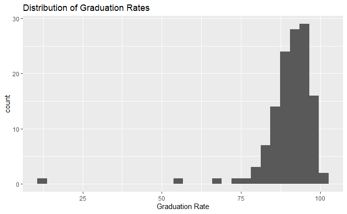

```r
districts %>%
  ggplot(aes(x = grad)) +
    geom_histogram() +
    ggtitle("Distribution of Graduation Rates") +
    xlab("Graduation Rate")
```

```
Warning: Removed 17 rows containing non-finite values (stat_bin).
```

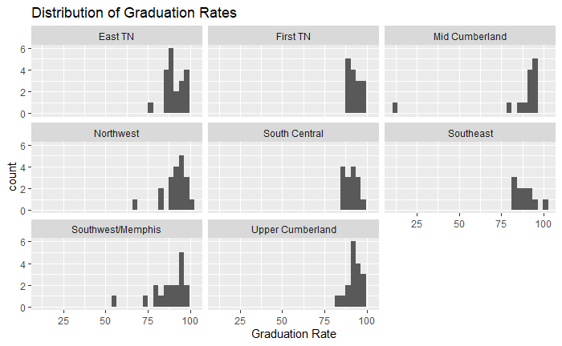

```r
districts %>%
  ggplot(aes(x = grad)) +
    geom_histogram() +
    ggtitle("Distribution of Graduation Rates") +
    xlab("Graduation Rate") +
    facet_wrap(~ region)
```

### Answer 8

The distribution is heavily left skewed, with a few low outliers.

## Problem 9

Create a scatter plot to compare alg_1 proficiency rates to alg_2 rates. What do you notice? Facet this plot by region. Does anything stand out when you facet the plots?

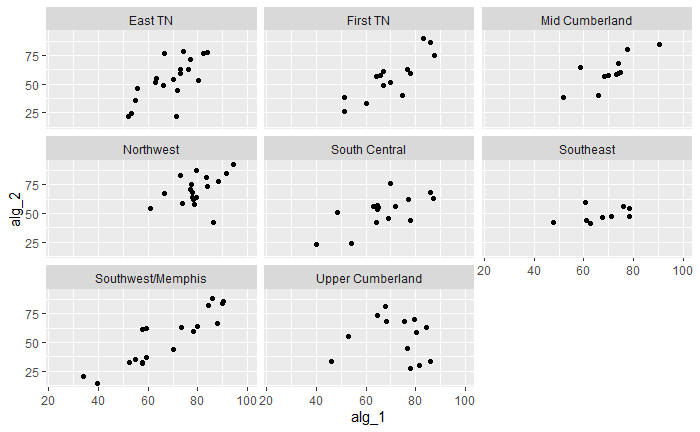

```r
districts %>%
  ggplot(aes(x = alg_1, y = alg_2)) +
    geom_point() +
    facet_wrap(~ region)
```

### Answer 9

alg_1 and alg_2 tend to be positively correlated.The exceptions appear to be Southeast and Upper Cumberland.

## Problem 10

Create a bar chart showing the total enrollment by region. Which region has the highest total enrollment? Which has the smallest?

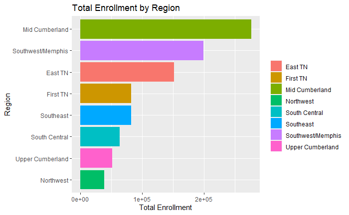

```r
districts %>%
  group_by(region) %>%
  summarize(total_enrollment = sum(enrollment, na.rm = TRUE)) %>%
  mutate(regionfct = factor(region)) %>%
  mutate(regionfct = fct_reorder(regionfct, total_enrollment, .desc = FALSE)) %>%
  ggplot(aes(y = regionfct , x = total_enrollment, fill = region)) +
    geom_col() +
    theme(legend.title = element_blank()) +
    labs(title = "Total Enrollment by Region",
         x = "Total Enrollment",
         y = "Region")
```

### Answer 10

Mid Cumberland has the highest total enrollment; Northwest has the lowest total enrollment.

## Problem 11

When creating this bar chart you may have noticed that some districts have missing enrollment values. For how many districts is this the case?

```r
districts %>%
  group_by(region) %>%
  summarize(na_count = sum(is.na(enrollment))) %>%
  arrange(desc(na_count), region)
```

| region | na_count |
| --- | --- |
| East TN | 1 |
| Mid Cumberland | 1 |
| Southwest/Memphis | 1 |
| Upper Cumberland | 1 |
| First TN | 0 |
| Northwest | 0 |
| South Central | 0 |
| Southeast | 0 |

### Answer 11

The regions with an NA are East TN, Mid Cumberland, Southwest/Memphis, and Upper Cumberland.

## Problem 12

What is the mean graduation rate across all districts? What might be wrong with using just the regular mean to assess average graduation rates?

```r
districts %>%
  summarize(mean_grad = mean(grad, na.rm = TRUE))
```

| mean_grad |
| --- |
| 90.06562 |

### Answer 12

The mean graduation rate across all districts is about 90.1%. Using the regular mean to assess graduation rates assumes that all districts should have equal weight in calculating the mean; however, some districts might represent more or less students than others.

## Problem 13

Redo the previous question but use a weighted average (weighted.mean) graduation across all districts, weighing by enrollment. How much does this change your answer? Can you explain using the data the reason for the big change from using the mean?

```r
districts %>%
  summarize(weighted_mean_grad = weighted.mean(grad, coalesce(enrollment,0), na.rm = TRUE))
```

| weighted_mean_grad |
| --- |
| 87.33285 |

```r
districts %>%
  group_by(region) %>%
  summarize(region_weighted_grad = weighted.mean(grad, coalesce(enrollment, 0), na.rm = TRUE)) %>%
  arrange(desc(region_weighted_grad))
```

| region | region_weighted_grad |
| --- | --- |
| Upper Cumberland | 92.24062 |
| First TN | 91.91454 |
| Northwest | 91.57705 |
| South Central | 90.47392 |
| East TN | 89.87089 |
| Mid Cumberland | 88.53965 |
| Southeast | 85.95494 |
| Southwest/Memphis | 79.45971 |

```r
NA
```

### Answer 13

The weighted mean graduation rate across all districts is about 87.3%, which is nearly 3% lower than the regular mean. This is not surprising given that the three regions with the highest enrollment are also three of the four with the lowest weighted mean graduation rates.

## Problem 14

Create a boxplot showing enrollment rates per region. Does anything stand out?

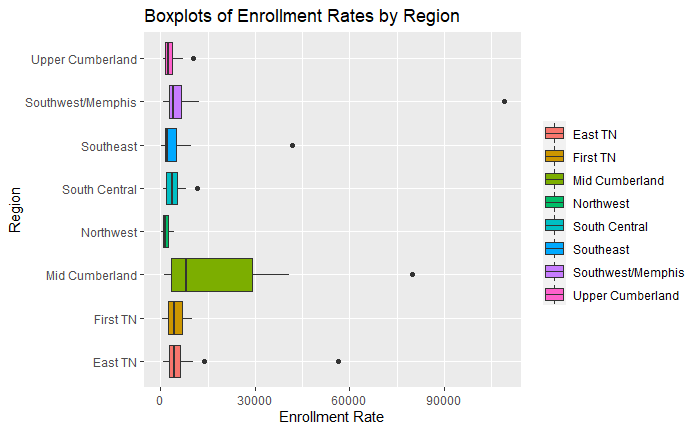

```r
districts %>%
  ggplot(aes(y = region, x = enrollment, fill = region)) +
    geom_boxplot() +
    theme(legend.title=element_blank()) +
    labs(title = "Boxplots of Enrollment Rates by Region",
         x = "Enrollment Rate",
         y = "Region")
```

```r
NA
```

### Answer 14

Enrollments of school districts are right-skewed. With the exception of Northwest and First TN, each region has at least one outlier district with unusually high enrollment (and Southwest/Memphis with one that’s just ridiculous.) Also, Mid Cumberland has by far the most variation, including in its IQR.

## Problem 15

Create a boxplot showing graduation rates per region. Does anything stand out?

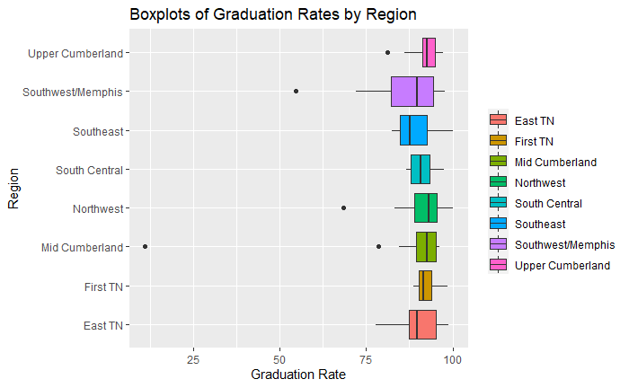

```r
districts %>%
  group_by(region) %>%
  ggplot(aes(y = region, x = grad, fill = region)) +
    geom_boxplot() +
    theme(legend.title=element_blank()) +
    labs(title = "Boxplots of Graduation Rates by Region",
         x = "Graduation Rate",
         y = "Region")
```

```r
NA
```

### Answer 15

Graduation rates of school districts are largely left-skewed or normal with low outliers. Mid Cumberland has a ridiculously low outlier (TN School for the Blind).Southwest/Memphis has the highest variation, including in its IQR.

## Problem 16

Find the weighted average of graduation rates by region using enrollment as weights. Compare the results you get for the weighted average to what you see from the boxplots. Can you explain any discrepancy? (Did this in Problem 13, as well.)

```r
districts %>%
  group_by(region) %>%
  summarize(region_weighted_grad = weighted.mean(grad, coalesce(enrollment, 0), na.rm = TRUE), region_median_grad = median(grad, na.rm = TRUE)) %>%
  arrange(desc(region_weighted_grad))
```

| region | region_weighted_grad | region_median_grad |
| --- | --- | --- |
| Upper Cumberland | 92.24062 | 92.60 |
| First TN | 91.91454 | 91.50 |
| Northwest | 91.57705 | 93.20 |
| South Central | 90.47392 | 90.80 |
| East TN | 89.87089 | 89.70 |
| Mid Cumberland | 88.53965 | 92.50 |
| Southeast | 85.95494 | 87.60 |
| Southwest/Memphis | 79.45971 | 89.85 |

```r
districts %>%
  filter(region == "Southwest/Memphis") %>%
  slice_min(grad, n = 3) %>%
  select(system_name, enrollment, grad)
```

| system_name | enrollment | grad |
| --- | --- | --- |
| Achievement School District | 6370 | 54.7 |
| Shelby County | 108936 | 72.1 |
| Millington City | 2597 | 78.2 |

```r
districts %>%
  filter(region == "Southwest/Memphis") %>%
  transmute(system_name, enrollment, enrollment_proportion = enrollment/sum(enrollment, na.rm = TRUE), grad) %>%
  arrange(desc(enrollment_proportion))
```

| system_name | enrollment | enrollment_proportion | grad |
| --- | --- | --- | --- |
| Shelby County | 108936 | 0.546980051 | 72.1 |
| Jackson-Madison County | 12280 | 0.061659277 | 94.5 |
| Tipton County | 11029 | 0.055377864 | 97.8 |
| Bartlett City | 8235 | 0.041348872 | 81.3 |
| Collierville City | 7774 | 0.039034139 | 93.0 |
| Achievement School District | 6370 | 0.031984495 | 54.7 |
| Germantown City | 5624 | 0.028238744 | 88.7 |
| Arlington City | 4819 | 0.024196747 | 94.0 |
| Lauderdale County | 4263 | 0.021405008 | 97.0 |
| McNairy County | 4136 | 0.020767327 | 94.3 |

[output cut: 11 more lines]

### Answer 16

Southwest/Memphis has a median graduation rate comparable to other districts; however, it’s weighted graduation rate is significantly lower than all other districts. This is partially because of The Achievement School District’s low graduation rate; however, it is primarily because Shelby County has a graduation rate of 72.1 (pretty low) and has an enrollment of 108,936, which is about 9 times as high as the next highest district in the region.

## Problem 17

For many districts, values for alg_2 are lower than for alg_1. Create a histogram showing the distribution of differences (alg_1 - alg_2).

```
Warning: Removed 28 rows containing non-finite values (stat_bin).
```

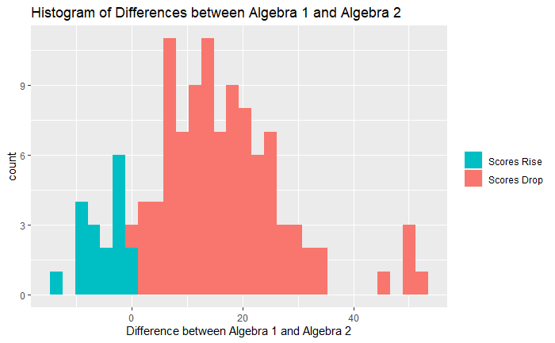

```r
districts_algebra <- districts %>%
  mutate(alg_diff = alg_1 - alg_2)

ggplot(districts_algebra, aes(x = alg_diff, fill = alg_diff < 0)) +
  geom_histogram() +
  theme(legend.title=element_blank()) +
  scale_fill_discrete(name = "",
                      labels = c("Scores Drop", "Scores Rise"),
                      guide = guide_legend(reverse=TRUE)) +
  labs(title = "Histogram of Differences between Algebra 1 and Algebra 2",
       x = "Difference between Algebra 1 and Algebra 2")
```

```r
NA
```

Which school had the largest drop from alg_1 to alg_2?

```r
districts_algebra %>%
  select(system_name, region, alg_diff) %>%
  arrange(desc(alg_diff))
```

| system_name | region | alg_diff |
| --- | --- | --- |
| Pickett County | Upper Cumberland | 52.6 |
| Fentress County | Upper Cumberland | 51.0 |
| Overton County | Upper Cumberland | 50.3 |
| Campbell County | East TN | 49.6 |
| Humboldt City | Northwest | 44.5 |
| Johnson County | First TN | 34.7 |
| Moore County | South Central | 34.5 |
| Macon County | Upper Cumberland | 32.0 |
| McMinn County | Southeast | 31.0 |
| Lewis County | South Central | 30.6 |

[output cut: 135 more lines]

For what percentage of schools is it true that alg_2 is larger than alg_1? Is there a similar dropoff for eng_2 and eng_3?

```r
districts_algebra %>%
  mutate(eng23_diff = eng_2 - eng_3) %>%
  summarize(proportion_alg_drop = mean(alg_diff < 0, na.rm = TRUE),
            proportion_eng23_drop = mean(eng23_diff < 0, na.rm = TRUE))
```

| proportion_alg_drop | proportion_eng23_drop |
| --- | --- |
| 0.1538462 | 0.007936508 |

### Answers 17

Pickett County had the highest proportion of scores drop from alg_1 to alg_2 (52.6%). Interestingly, the three highest are all in the Upper Cumberland region. In only about 15.4% of districts do alg_2 scores increase from alg_1. The case with eng_2 to eng_3 is even more dramatic, with only 0.8% of districts seeing an improvement in scores.

18. You may have noticed that a lot of rows are missing values. Which district has the largest number of missing values? What do you notice about schools that have a lot of missing values?

```r
districts %>%
  mutate(count_nas = rowSums(is.na(.))) %>%
  arrange(desc(count_nas))
```

| system | system_name | alg_1 | alg_2 | bio | chem | ela | eng_1 | eng_2 | eng_3 | math | science | enrollment | black | hispanic | native | el | swd | ed | expenditures | act_composite | chronic_abs | suspended | expelled | grad | dropout | region | count_nas |
| --- | --- | --- | --- | --- | --- | --- | --- | --- | --- | --- | --- | --- | --- | --- | --- | --- | --- | --- | --- | --- | --- | --- | --- | --- | --- | --- | --- |
| 960 | West Tenn School for Deaf | NA | NA | NA | NA | NA | NA | NA | NA | NA | NA | NA | 48.7 | 7.7 | 0.0 | 0.0 | 97.4 | 76.9 | NA | NA | 23.1 | 0.0 | 0.0 | NA | NA | Southwest/Memphis | 15 |
| 11 | Clinton City | NA | NA | NA | NA | 58.3 | NA | NA | NA | 68.9 | 69.6 | 894 | 5.7 | 2.8 | 0.3 | 1.0 | 18.1 | 63.4 | 9537.5 | NA | 8.8 | 1.2 | 0.0 | NA | NA | East TN | 10 |
| 151 | Newport City | NA | NA | NA | NA | 56.9 | NA | NA | NA | 55.3 | 84.6 | 717 | 7.1 | 3.0 | 0.5 | 0.8 | 14.4 | 58.0 | 9216.2 | NA | 11.8 | 0.1 | 0.0 | NA | NA | First TN | 10 |
| 161 | Manchester City | NA | NA | NA | NA | 53.6 | NA | NA | NA | 59.0 | 71.8 | 1211 | 5.8 | 14.6 | 0.5 | 10.0 | 20.9 | 23.6 | 12309.4 | NA | 10.2 | 0.4 | 0.0 | NA | NA | South Central | 10 |
| 171 | Alamo City | NA | NA | NA | NA | 53.5 | NA | NA | NA | 62.8 | 74.6 | 578 | 11.6 | 16.7 | 0.0 | 1.1 | 11.4 | 69.9 | 8669.4 | NA | 7.8 | 0.2 | 0.0 | NA | NA | Northwest | 10 |
| 172 | Bells City | NA | NA | NA | NA | 60.8 | NA | NA | NA | 60.8 | 79.5 | 365 | 16.3 | 21.0 | 0.0 | 13.2 | 13.2 | 74.1 | 8817.6 | NA | 3.2 | 0.2 | 0.0 | NA | NA | Northwest | 10 |
| 371 | Rogersville City | NA | NA | NA | NA | 61.6 | NA | NA | NA | 65.3 | 80.2 | 617 | 4.2 | 2.3 | 0.3 | 1.7 | 11.7 | 52.2 | 9441.7 | NA | 8.8 | 0.0 | 0.0 | NA | NA | First TN | 10 |
| 391 | Lexington City | NA | NA | NA | NA | 46.7 | NA | NA | NA | 67.0 | 70.2 | 925 | 25.0 | 6.5 | 0.1 | 1.9 | 13.2 | 62.0 | 9925.9 | NA | 10.8 | 0.0 | 0.0 | NA | NA | Southwest/Memphis | 10 |
| 542 | Etowah City | NA | NA | NA | NA | 38.8 | NA | NA | NA | 40.2 | 66.5 | 310 | 6.8 | 4.1 | 0.6 | 0.0 | 15.1 | 74.0 | 10807.6 | NA | 13.6 | 3.6 | 0.0 | NA | NA | Southeast | 10 |
| 621 | Sweetwater City | NA | NA | NA | NA | 50.1 | NA | NA | NA | 59.9 | 61.4 | 1509 | 7.5 | 9.0 | 0.2 | 0.4 | 19.6 | 79.1 | 8332.0 | NA | 10.0 | 2.4 | 0.0 | NA | NA | East TN | 10 |

[output cut: 135 more lines]

### Answer 18

Schools with many missing values tend to be missing the same values: testing data. Therefore, with the exception of the district with the highest number of missing values (West TN School for the Deaf, with 15), the districts with the most missing values all have 10 NAs. It’s also worth noting that 11 of the 13 districts with the most missing values have “City” in their name. Do cities report testing data elsewhere?

19. Find the correlation between graduation rate and all other variables. Create a horizontal bar chart showing these correlations. Make sure that your plot is ordered by correlation values. What do you notice from these correlations?

```r
(grad_corrs <- districts %>%
  select(where(is.numeric)) %>%
  correlate(use = "pairwise.complete.obs") %>%
  select(term, grad)) %>%
  arrange(grad)
```

```
Correlation method: 'pearson'
Missing treated using: 'pairwise.complete.obs'
```

| term | grad |
| --- | --- |
| swd | -0.55552703 |
| chronic_abs | -0.51492981 |
| dropout | -0.50389017 |
| expenditures | -0.42661800 |
| black | -0.40798847 |
| enrollment | -0.30108493 |
| suspended | -0.28196098 |
| system | -0.21637680 |
| hispanic | -0.17747659 |
| expelled | -0.16041908 |

[output cut: 15 more lines]

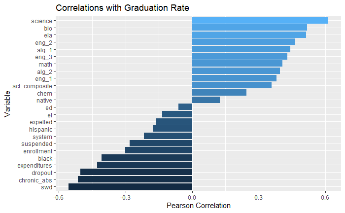

```r
ggplot(grad_corrs%>%drop_na(), aes(y = reorder(term, grad), x = grad, fill = grad)) +
  geom_col() +
  #geom_text(aes(label=grad), position=position_dodge(width=0.9)) +
  theme(legend.position = 'none') +
  labs(title = "Correlations with Graduation Rate",
       x = "Pearson Correlation",
       y = "Variable")
```

## Problem 20

Create a scatterplot for grad vs. suspended. Does what you see make sense given your answer from the previous part?

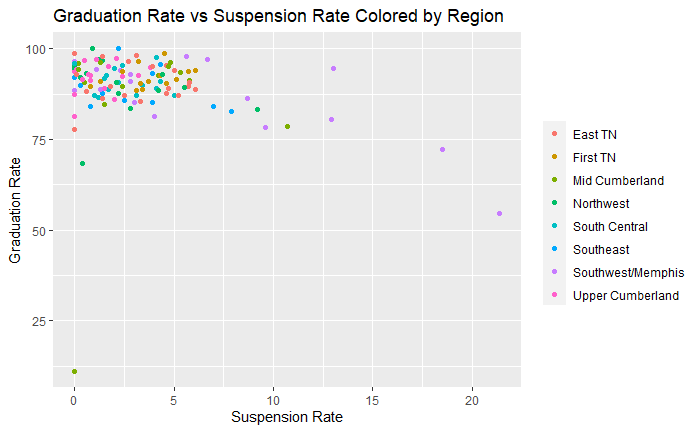

```r
ggplot(districts, aes(x = suspended, y = grad)) +
  geom_point(aes(color = region)) +
  theme(legend.title=element_blank()) +
  labs(title = "Graduation Rate vs Suspension Rate Colored by Region",
       x = "Suspension Rate",
       y = "Graduation Rate")
```

### Answer 20

Sure enough, as suspension rate increases, graduation rate tends to decrease (i.e. negative correlation).

21. Create a linear regression model using lm with target variable grad and predictor variable suspended. What R^2 value does this model have? What is the interpretation of this number?

```r
lm_grad_susp = lm(grad~suspended, data = districts) #Create the linear regression
summary(lm_grad_susp)
```

```
Call:
lm(formula = grad ~ suspended, data = districts)

Residuals:
    Min      1Q  Median      3Q     Max
-81.407  -2.271   1.190   3.934  12.208

Coefficients:
            Estimate Std. Error t value Pr(>|t|)
(Intercept)  92.5071     1.0924  84.679  < 2e-16 ***
suspended    -0.7858     0.2382  -3.299  0.00126 **
---
Signif. codes:  0 ‘***’ 0.001 ‘**’ 0.01 ‘*’ 0.05 ‘.’ 0.1 ‘ ’ 1

Residual standard error: 9.091 on 126 degrees of freedom
  (17 observations deleted due to missingness)
Multiple R-squared:  0.0795,    Adjusted R-squared:  0.0722
F-statistic: 10.88 on 1 and 126 DF,  p-value: 0.001262
```

```r
summary(lm_grad_susp)$r.squared
```

```
[1] 0.079502
```

### Answer 21

The R^2 value of this model is 0.079502, which means that the model explains about 8% of the variability in the data.

22. Add the regression line to your scatterplot using geom_smooth with method=‘lm’. How do you feel about the regression line after seeing it plotted on the scatterplot?

```
Warning: Removed 17 rows containing non-finite values (stat_smooth).
Warning: Removed 17 rows containing missing values (geom_point).
```

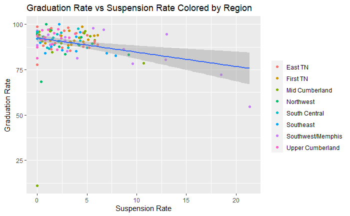

```r
ggplot(districts, aes(x = suspended, y = grad)) +
  geom_point(aes(color = region)) +
  geom_smooth(method = 'lm') +
  theme(legend.title=element_blank()) +
  labs(title = "Graduation Rate vs Suspension Rate Colored by Region",
       x = "Suspension Rate",
       y = "Graduation Rate")
```

### Answer 22

Given the R^2 found in Problem 21, the line looks useful for demonstrating the decreasing trend but not for predicting specific graduation rates.

Continued Exploration and Practice

23. Read in the school-level testing data for 2014, available here. You might find the readxl library useful for this task. If you use this library, be sure to look at the na argument for the read_excel function.

```r
(schools <- read_excel('../data/data_2014_school_base.xlsx', na = "*"))
```

| year | system | system_name | school | school_name | subject | grade | subgroup | valid_tests | n_below_bsc | n_bsc | n_prof | n_adv | pct_below_bsc | pct_bsc | pct_prof | pct_adv | pct_bsc_and_below | pct_prof_adv |
| --- | --- | --- | --- | --- | --- | --- | --- | --- | --- | --- | --- | --- | --- | --- | --- | --- | --- | --- |
| 2014 | 10 | Anderson County | 2 | Anderson County High School | Algebra I | All Grades | All Students | 225 | 15 | 39 | 79 | 92 | 6.7 | 17.3 | 35.1 | 40.9 | 24.0 | 76.0 |
| 2014 | 10 | Anderson County | 2 | Anderson County High School | Algebra I | All Grades | White | 222 | 13 | 39 | 79 | 91 | 5.8 | 17.600000000000001 | 35.6 | 41 | 23.4 | 76.6 |
| 2014 | 10 | Anderson County | 2 | Anderson County High School | Algebra I | All Grades | Black | 1 | NA | NA | NA | NA | NA | NA | NA | NA | NA | NA |
| 2014 | 10 | Anderson County | 2 | Anderson County High School | Algebra I | All Grades | Asian | 1 | NA | NA | NA | NA | NA | NA | NA | NA | NA | NA |
| 2014 | 10 | Anderson County | 2 | Anderson County High School | Algebra I | All Grades | Native American | 1 | NA | NA | NA | NA | NA | NA | NA | NA | NA | NA |
| 2014 | 10 | Anderson County | 2 | Anderson County High School | Algebra I | All Grades | Economically Disadvantaged | 116 | 12 | 26 | 43 | 35 | 10.3 | 22.4 | 37.1 | 30.2 | 32.7 | 67.3 |
| 2014 | 10 | Anderson County | 2 | Anderson County High School | Algebra I | All Grades | Students with Disabilities | 35 | 9 | 12 | 9 | 5 | 25.7 | 34.299999999999997 | 25.7 | 14.3 | 60.0 | 40.0 |
| 2014 | 10 | Anderson County | 2 | Anderson County High School | Algebra I | All Grades | Black/Hispanic/Native American | 2 | NA | NA | NA | NA | NA | NA | NA | NA | NA | NA |
| 2014 | 10 | Anderson County | 2 | Anderson County High School | Algebra I | All Grades | Non-Economically Disadvantaged | 109 | 3 | 13 | 36 | 57 | 2.8 | 11.9 | 33 | 52.3 | 14.7 | 85.3 |
| 2014 | 10 | Anderson County | 2 | Anderson County High School | Algebra I | All Grades | Non-Students with Disabilities | 190 | 6 | 27 | 70 | 87 | 3.2 | 14.2 | 36.799999999999997 | 45.8 | 17.4 | 82.6 |

[output cut: 990 more lines]

24. How many schools have at least 20 percent of students below bsc for Algebra I? Which districts do these schools belong to?

```r
bad_alg_schools <- schools %>%
  mutate(pct_below_bsc = as.integer(pct_below_bsc)) %>%
  filter((subject == "Algebra I") & (subgroup == "All Students") & (grade == "All Grades") & (pct_below_bsc >= 20))
bad_alg_schools %>%
  count()
```

| n |
| --- |
| 71 |

```r
bad_alg_schools %>%
  distinct(system_name)
```

| system_name |
| --- |
| Bedford County |
| Bledsoe County |
| Maryville |
| Bradley County |
| Campbell County |
| Hollow Rock-Bruceton |
| Cheatham County |
| Claiborne County |
| Cumberland County |
| Davidson County |

[output cut: 20 more lines]

### Answer 24

There are 71 schools with at least 20 percent of students below bsc for Algebra I. These are contained in 30 distinct school districts, displayed above.

25. How many schools have at least 20 percent of students below bsc for both Algebra I and English I?

```r
schools %>%
  mutate(pct_below_bsc = as.integer(pct_below_bsc)) %>%
  filter((subject %in% c("Algebra I", "English I"))
         & (subgroup == "All Students")
         & (grade == "All Grades")
         ) %>%
  select(system_name, school_name, subject, pct_below_bsc) %>%
  pivot_wider(names_from = subject, values_from = pct_below_bsc) %>%
  filter(!is.na(`Algebra I`) & !is.na(`English I`)) %>%
  summarize(count_both_min_20 = sum(`Algebra I`>=20 & `English I`>=20),
            mean_both_min_20 = mean(`Algebra I`>=20 & `English I`>=20))
```

| count_both_min_20 | mean_both_min_20 |
| --- | --- |
| 4 | 0.01428571 |

```r
schools %>%
  mutate(pct_below_bsc = as.integer(pct_below_bsc)) %>%
  filter((subject %in% c("Algebra I", "English I"))
         & (subgroup == "All Students")
         & (grade == "All Grades")
         ) %>%
  select(system_name, school_name, subject, pct_below_bsc) %>%
  pivot_wider(names_from = subject, values_from = pct_below_bsc) %>%
  filter(!is.na(`Algebra I`) & !is.na(`English I`) & `Algebra I`>=20 & `English I`>=20)
```

| system_name | school_name | Algebra I | English I |
| --- | --- | --- | --- |
| Campbell County | Jellico High School | 23 | 21 |
| Davidson County | Stratford STEM Magnet High School | 35 | 22 |
| Lake County | Lake County High School | 22 | 20 |
| Shelby County (New) | Northside High School | 31 | 30 |

### Answer 25

Four schools have at least 20 percent of students below bsc for both Algebra I and English I: * Jellico High School * Stratford STEM Magnet High School * Lake County High School * Northside High School

26. Which grade has the highest pct_adv for Algebra I? Plot the average pct_adv per grade level as a bar chart. Make sure that the bars are ordered by grade level.

```r
mean_pct_adv_by_grade <- schools %>%
  mutate(pct_adv = as.numeric(pct_adv)) %>%
  filter(subject == 'Algebra I' & subgroup == "All Students" & !(grade %in% c("Missing Grade", "All Grades"))) %>%
  group_by(grade) %>%
  summarize(mean_pct_adv = mean(pct_adv, na.rm = TRUE))
mean_pct_adv_by_grade%>%
  slice_max(mean_pct_adv, n = 1)
```

| grade | mean_pct_adv |
| --- | --- |
| 8 | 35.52381 |

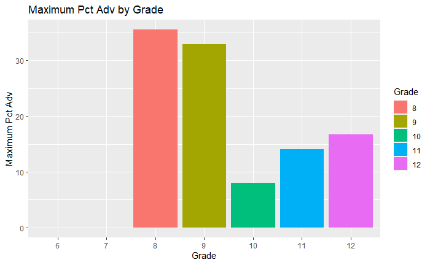

```r
mean_pct_adv_by_grade %>%
  mutate(grade = factor(grade, levels = c('6','7', '8', '9', '10', '11', '12'))) %>%
  ggplot(aes(x = grade, y = mean_pct_adv, fill = grade)) +
    geom_col() +
    labs(title = "Maximum Pct Adv by Grade",
         x = "Grade",
         y = "Maximum Pct Adv") +
    scale_fill_discrete(name = "Grade")
```

### Answer 26

8th grade has the highest mean pct_adv for Algebra I with about 35.52%.

27. Find the correlation between pct_adv for Algebra I and pct_adv for Algebra II by school. Create a scatterplot showing Algebra II scores vs. Algebra I scores by school.

```r
alg12_by_school <- schools %>%
  mutate(pct_adv = as.numeric(pct_adv)) %>%
  filter(subject %in% c('Algebra I', 'Algebra II') & subgroup == "All Students" & grade == "All Grades") %>%
  select(system_name, school_name, subject, pct_adv) %>%
  pivot_wider(names_from = subject, values_from = pct_adv)
alg12_by_school %>%
  select(`Algebra I`, `Algebra II`) %>%
  cor(use = "pairwise.complete.obs")
```

```
           Algebra I Algebra II
Algebra I  1.0000000  0.6026042
Algebra II 0.6026042  1.0000000
```

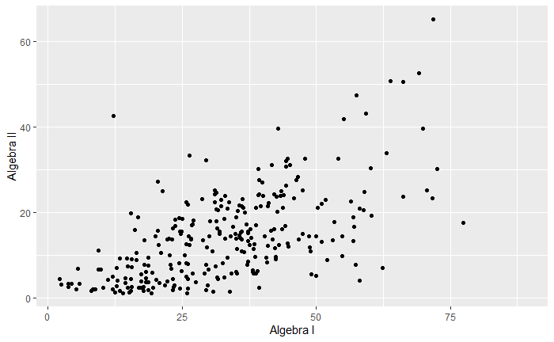

```r
ggplot(alg12_by_school, aes(x = `Algebra I`, y = `Algebra II`)) +
  geom_point()
```

### Answer 27

The correlation between pct_adv of Algebra 1 and Algebra 2 is 0.602 (pretty strong, given the number of points).

28. Find all schools in Rutherford County that have “High School” in their name. For these schools, create a chart (your choice) showing the differences in pct_below_bsc, pct_bsc, pct_prof, and pct_adv for Algebra I when looking across all subgroups and grades.

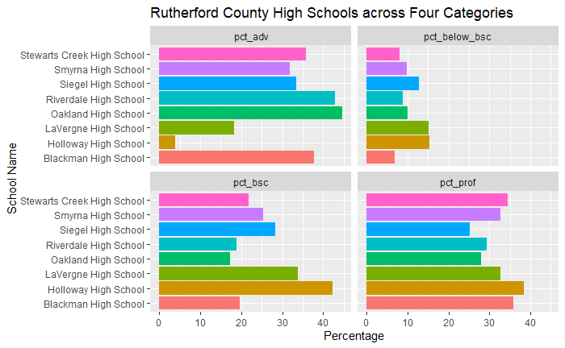

```r
schools %>%
  filter(system_name == "Rutherford County" &
         grepl("High School", school_name) &
         subject == "Algebra I" &
         grade == "All Grades" &
         subgroup == "All Students") %>%
  select(system_name, school_name, pct_below_bsc, pct_bsc, pct_prof, pct_adv) %>%
  pivot_longer(names_to = "category", values_to = "percentage", cols = c(pct_below_bsc, pct_bsc, pct_prof, pct_adv)) %>%
  mutate(percentage = as.numeric(percentage)) %>%
  ggplot(aes(y = school_name, x = percentage, fill = school_name)) +
    geom_col() +
    facet_wrap(~category) +
    theme(legend.position = "none") +
    labs(title = "Rutherford County High Schools across Four Categories",
         y = "School Name",
         x = "Percentage")
```

```r
NA
```

29. I claim that smaller schools do a better job preparing students for Algebra I standardized tests. Find the average number of valid tests (a proxy for the school size) for schools where the pct_prof_adv for Algebra I is greater than 95. Compare this to the average number of valid tests for all schools. In light of this result, how does my claim look?

[output not shown]

```r
all_valid_tests <- schools %>%
  filter(subject == "Algebra I" &
         grade == "All Grades" &
         subgroup == "All Students"
        ) %>%
  select(valid_tests)

high_valid_tests <- schools %>%
  filter(subject == "Algebra I" &
         grade == "All Grades" &
         subgroup == "All Students" &
         as.numeric(pct_prof_adv) > 95
        ) %>%
  select(valid_tests)

t.test(all_valid_tests, high_valid_tests)
```

```
    Welch Two Sample t-test

data:  all_valid_tests and high_valid_tests
t = 13.243, df = 748.76, p-value < 2.2e-16
alternative hypothesis: true difference in means is not equal to 0
95 percent confidence interval:
 69.42199 93.58677
sample estimates:
mean of x mean of y
129.95017  48.44578
```

### Answer 29

30. I also claim that smaller schools do a worse job preparing students for Algebra I standardized tests. Find the average number of valid tests (a proxy for the school size) for schools where the pct_prof_adv for Algebra I is less than 25. Compare this to the average number of valid tests for all schools. In light of this result, how does my claim look now?

```r
schools %>%
  filter(subject == "Algebra I" &
         grade == "All Grades" &
         subgroup == "All Students"
        ) %>%
  mutate(pct_prof_adv_under_25 = as.numeric(pct_prof_adv) < 25) %>%
  summarize(mean_valid_tests = mean(valid_tests, rm.na = TRUE),
            count_valid_tests = n(),
            mean_valid_tests_low_scores = weighted.mean(valid_tests, coalesce(pct_prof_adv_under_25,0), na.rm = TRUE),
            count_valid_tests_low_scores = sum(pct_prof_adv_under_25, na.rm = TRUE)
            )
```

| mean_valid_tests | count_valid_tests | mean_valid_tests_low_scores | count_valid_tests_low_scores |
| --- | --- | --- | --- |
| 129.9502 | 602 | 62.08696 | 23 |

```r
all_valid_tests <- schools %>%
  filter(subject == "Algebra I" &
         grade == "All Grades" &
         subgroup == "All Students"
        ) %>%
  select(valid_tests)

low_valid_tests <- schools %>%
  filter(subject == "Algebra I" &
         grade == "All Grades" &
         subgroup == "All Students" &
         as.numeric(pct_prof_adv) < 25
        ) %>%
  select(valid_tests)

t.test(all_valid_tests, low_valid_tests)
```

```
    Welch Two Sample t-test

data:  all_valid_tests and low_valid_tests
t = 5.3732, df = 32.001, p-value = 6.707e-06
alternative hypothesis: true difference in means is not equal to 0
95 percent confidence interval:
 42.13690 93.58952
sample estimates:
mean of x mean of y
129.95017  62.08696
```

### Answer 30

Right; so here we see the if vs. only if thing. We’re seeing that both lower and higher scores tend to be associated with smaller-than-average schools. Both of your statements are overly general, and they should probably be finessed to something more like “Higher Algebra I scores tend to occur in smaller schools,” and “Lower Algebra I scores tend to be associated with smaller schools.” Note this might just mean that smaller schools tend to be high variation and not that their mean outcomes significantly differ from the overall mean. Perhaps to more directly check your statements, we’d want to see whether the pct_prof_adv of Algebra I for schools with low valid_test counts (we’d have to pick a threshold for “low”) tends to be significantly different from the overall mean scores.

31. Create a scatterplot showing pct_prov_adv vs. valid_tests. Can you use this to explain the result for numbers 26 and 27?

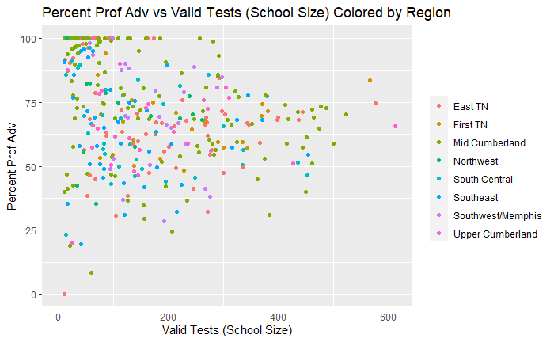

```r
schools %>%
  inner_join(districts) %>%
  filter(subject == "Algebra I" &
         grade == "All Grades" &
         subgroup == "All Students"
        ) %>%
ggplot(aes(x = valid_tests, y = pct_prof_adv, color = region)) +
  geom_point() +
  theme(legend.title = element_blank()) +
  labs(title = "Percent Prof Adv vs Valid Tests (School Size) Colored by Region",
       x = "Valid Tests (School Size)",
       y = "Percent Prof Adv")
```

```r
NA
```

### Answer 31

Values above 95 or below 25 are almost exclusively paired with small school sizes, while increased school sizes tend to pair with moderate Percent Prof Adv. So, yeah, that tracks.

If you finish all of the above questions, continue to explore the two datasets and see what else interesting you can find.

Also, check out the plotly library for R. The ggplotly function makes it very easy to convert ggplot plots into interactive plotly plots.